Reasons to use Rmarkdown

- It’s an easy way to combine `R` code and text in one document
- It creates well formatted and readable document
- It’s easier for you! You do not have to copy and paste plots or code
- You’ll make your markers happy!
- It will help you improve your workflow (i.e., helping your code to be reproducible)

# Types of content

Notice that this file contains three types of content:

- text mixed with simple text formatting
- An (optional) YAML header surrounded by `---`s
- `R` code chunks surrounded by three back ticks

## Plain text

I will be plain text

*I will be in italics* and *so will I*

**I will be in bold** and **so will I**

I will be a strikethrough

I will be a link

To make a level X (X = 1,…6) header use X hashes at the start of a line (see the headers in this document)

To make an inline equation: $A = \pi*r^{2}$

The following will put in a horizontal rule:

> I will be a block quote
- I am an unordered list
  - item 2
  - sub-item 1
  - sub-item 2
1. I am an ordered list
2. item 2
   - sub-item 1
   - sub-item 2

A table will be made:

| Table Header | Second Header |
| --- | --- |
| Table Cell | Cell 2 |
| Cell 3 | Cell 4 |

### Exercise: Write a brief paragraph explaing what is meant by good programming practice. Your text should include as many of the syntax examples above as you can. You can even look for more syntax options on the [Rmarkdown website](http://rmarkdown.rstudio.com)

## The YAML header

Use this to specify what you want to *knit* to (i.e., what format of document to produce). Popular options are

- PDF, `pdf_document`,
- HTML, `html_document`, and
- Word, `word_document`

For this lab we will be *knit*ing to HTML. This document is already set up to do so, see the very top of the page!

### Exercise: Change the title of this document to something informative and specific to this lab. Add in your name and the date too.

If you get an error that starts with `Error in yaml::yaml.load(...` when you *knit* you probably deleted a quotation mark by mistake.

## `R` code

To make a code chunk you use three back ticks followed by an r in braces and to end the chunk you again use three back ticks:

```r
paste("Hello", "World!")
```

```
## [1] "Hello World!"
```

To place code inline you would use single back ticks. The first back tick must be followed by an r: Hello World!.

### Chunk options

You add chunk options within the braces `{}`. For example, `echo = FALSE` will prevent source code from being displayed:

```
## [1] "Hello World!"
```

and `eval = FALSE` will prevent source code from being evaluated:

```r
paste("Hello", "World!")
```

Other useful chunk options include

- `error`, by default is `TRUE`; if `FALSE`, knitr will not display any error messages generated by the code.
- `message`, by default is `TRUE`; if `FALSE`, knitr will not display any messages generated by the code.
- `warning`, by default is `TRUE`; if `FALSE`, knitr will not display any warning messages generated by the code.
- `results`, by default is `markup`; if `hide`, knitr will not display the code’s results in the final document. If `hold`, knitr will delay displaying all output pieces until the end of the chunk. If `asis`, knitr will pass through results without reformatting them (useful if results return raw HTML, etc.)

To produce a plot

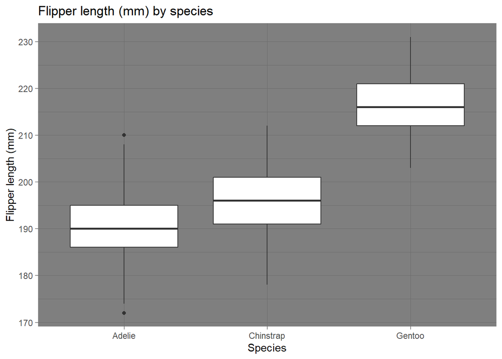

```r
library(palmerpenguins) ## install using install.packages() if not already installed
library(ggplot2) ## install using install.packages() if not already installed
ggplot(penguins,aes(x = species, y = flipper_length_mm)) + ## data & aesthetics
    geom_boxplot()  + ## geom
  ggtitle("Flipper length (mm) by species") +
  ylab("Flipper length (mm)") +
  xlab("Species") +
  theme_dark() ## theme
```

Plotting related chunk options include

- `fig.align`, how to align graphics in the final document. One of `lef`, `right`, or `center`.
- `fig.cap`, A character string to be used as a figure caption in LaTex.
- `fig.height` and `fig.width`, specify the width and height to use in R for plots created by the chunk (in inches). By default this is 7.
- `fig.alt`, allows you so include alternative text for the image.

### Exercise: Write a chunk of `R` code that carries out some basic manipulation on the `palmerpenguins` data. Include chunks that 1) both evaluates and prints the code, 2) only evaluates the code, and 3) only prints the code. Your code chunks should be integrated with text that details whether the examples you’ve given abide by programming best practices or not.

### Exercise: Write a chunk of `R` code that creates a basic plot of the `palmerpenguins` data. Include chunks that 1) both prints the code and shows the plot, 2) only shows the plot, and 3) only shows the plot with a figure caption included. Your code chunks should be integrated with text that details whether the examples you’ve given abide by programming best practices or not.

### And finally… Remove all content not written by you, *knit* to PDF or HTML, and upload your work to CANVAS.